# Homework 1

Onur Can

4/16/2021

This is project that is mainly focusing on unemployment and its potential parameters.Data used in this homework is from : https://evds2.tcmb.gov.tr/

##1 Selecting Predictor

After evaluation of many variables that has positive or negative relationship between unemploymeny , I have chosen five potential predictors that are capacity utilization rate of manufacturing , dollar exchange rate , firms statistics(newly established),interest rate,firms statistics(newly closed).

That is plot of unemployment for 85 weeks below.

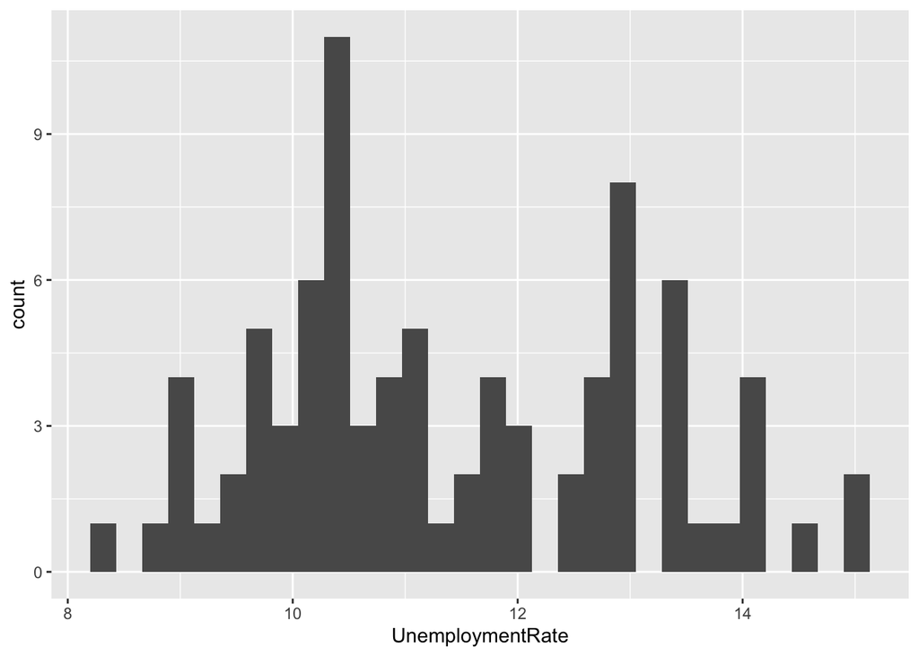

Data table and its structure is given below.

```
## Classes 'data.table' and 'data.frame':   85 obs. of  6 variables:
##  $ UnemploymentRate                      : num  10.5 10.5 9.4 8.8 8.4 9 9.7 10.1 10.1 10.9 ...
##  $ CapacityUtilizationRateofManufacturing: num  75.6 73.8 74.5 75.1 74.7 75.6 74.9 74.9 75.1 75.4 ...
##  $ DollarExchangeRate                    : num  2.22 2.21 2.22 2.13 2.09 ...
##  $ FirmsStatisticsNewlyEstablished       : num  907 758 788 794 811 839 925 817 900 857 ...
##  $ InterestRate                          : num  15 16.8 17.1 16.9 16.7 ...
##  $ FirmsStatisticsNewlyClosed            : num  2211 1012 868 718 768 ...
##  - attr(*, ".internal.selfref")=<externalptr>
```

Correlation between those variables is significant for our determination.Then, let us check correlation table ,first.After,we may observe shape of our graphs.

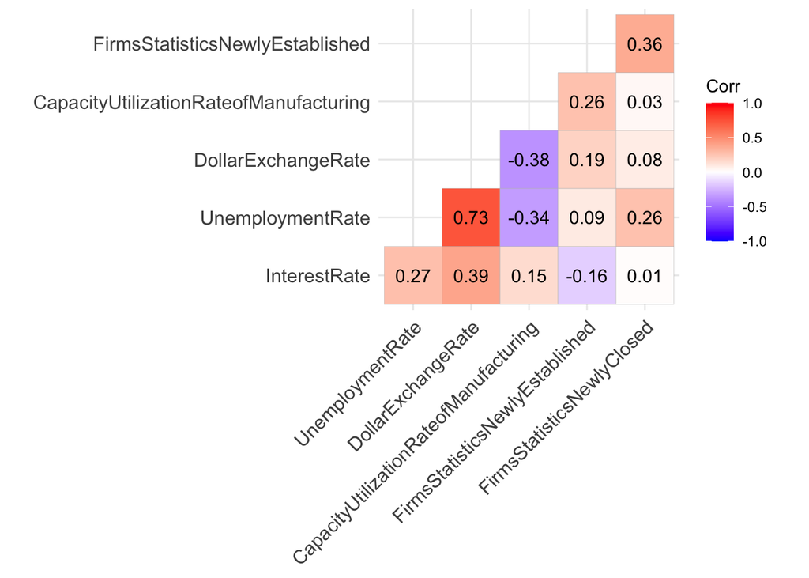

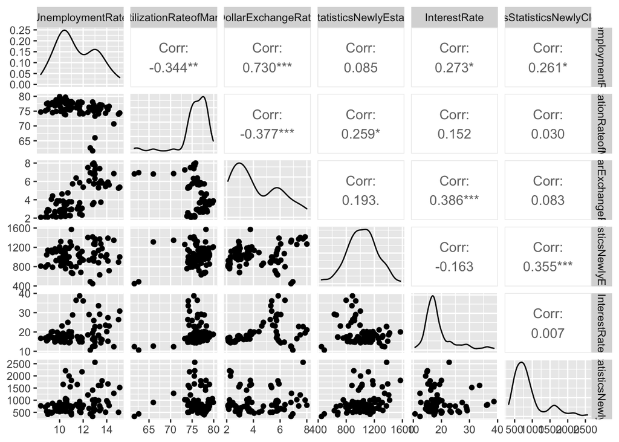

##2 Building Linear Model

Especially, we have nice correlationships for some indepedent variables,which pushes me to build linear model to check if our model is good enough or not.

Summary of inear regression model we build above helps us claim that we have good model because of p value of model that is 3.415e-14.

```
##
## Call:
## lm(formula = UnemploymentRate ~ CapacityUtilizationRateofManufacturing +
##     DollarExchangeRate + FirmsStatisticsNewlyEstablished + InterestRate +
##     FirmsStatisticsNewlyClosed, data = unemployment)
##
## Residuals:
##      Min       1Q   Median       3Q      Max
## -2.01269 -0.91406 -0.03366  0.67172  3.05735
##
## Coefficients:
##                                          Estimate Std. Error t value Pr(>|t|)
## (Intercept)                            10.3252234  3.7642301   2.743  0.00753
## CapacityUtilizationRateofManufacturing -0.0179654  0.0532415  -0.337  0.73669
## DollarExchangeRate                      0.7063895  0.0985465   7.168 3.56e-10
## FirmsStatisticsNewlyEstablished        -0.0010974  0.0007257  -1.512  0.13445
## InterestRate                           -0.0092052  0.0278546  -0.330  0.74192
## FirmsStatisticsNewlyClosed              0.0009024  0.0002777   3.249  0.00170
##
## (Intercept)                            **
## CapacityUtilizationRateofManufacturing
## DollarExchangeRate                     ***
## FirmsStatisticsNewlyEstablished
## InterestRate
## FirmsStatisticsNewlyClosed             **
## ---
## Signif. codes:  0 '***' 0.001 '**' 0.01 '*' 0.05 '.' 0.1 ' ' 1
##
## Residual standard error: 1.081 on 79 degrees of freedom
## Multiple R-squared:  0.5932, Adjusted R-squared:  0.5674
## F-statistic: 23.04 on 5 and 79 DF,  p-value: 3.415e-14
```

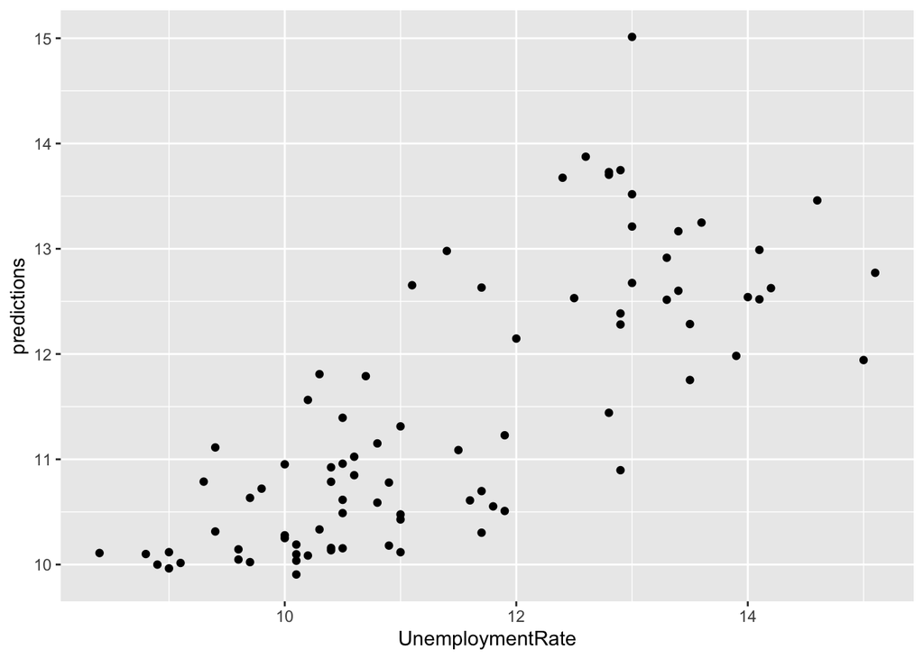

Variance seems a bit deviated.On the other hand,I can see positive linear relationship which indicates that I am on right way.

Then,we benefit from step function in R to question presences of independent variables in my model.

```
## Start:  AIC=19.05
## UnemploymentRate ~ CapacityUtilizationRateofManufacturing + DollarExchangeRate +
##     FirmsStatisticsNewlyEstablished + InterestRate + FirmsStatisticsNewlyClosed
##
##                                          Df Sum of Sq     RSS    AIC
## - InterestRate                            1     0.128  92.478 17.167
## - CapacityUtilizationRateofManufacturing  1     0.133  92.483 17.172
## <none>                                                 92.350 19.049
## - FirmsStatisticsNewlyEstablished         1     2.673  95.023 19.475
## - FirmsStatisticsNewlyClosed              1    12.340 104.690 27.710
## - DollarExchangeRate                      1    60.064 152.414 59.636
##
## Step:  AIC=17.17
## UnemploymentRate ~ CapacityUtilizationRateofManufacturing + DollarExchangeRate +
##     FirmsStatisticsNewlyEstablished + FirmsStatisticsNewlyClosed
##
##                                          Df Sum of Sq     RSS    AIC
## - CapacityUtilizationRateofManufacturing  1     0.396  92.873 15.530
## <none>                                                 92.478 17.167
## - FirmsStatisticsNewlyEstablished         1     2.738  95.216 17.647
## - FirmsStatisticsNewlyClosed              1    12.217 104.695 25.714
## - DollarExchangeRate                      1    89.124 181.602 72.529
##
## Step:  AIC=15.53
## UnemploymentRate ~ DollarExchangeRate + FirmsStatisticsNewlyEstablished +
##     FirmsStatisticsNewlyClosed
##
##                                   Df Sum of Sq     RSS    AIC
## <none>                                          92.873 15.530
## - FirmsStatisticsNewlyEstablished  1     4.098  96.972 17.200
## - FirmsStatisticsNewlyClosed       1    12.579 105.453 24.327
## - DollarExchangeRate               1   118.602 211.475 83.474
```

```
##
## Call:
## lm(formula = UnemploymentRate ~ DollarExchangeRate + FirmsStatisticsNewlyEstablished +
##     FirmsStatisticsNewlyClosed, data = unemployment)
##
## Coefficients:
##                     (Intercept)               DollarExchangeRate
##                       8.8080241                        0.7073769
## FirmsStatisticsNewlyEstablished       FirmsStatisticsNewlyClosed
##                      -0.0011251                        0.0009023
```

My evaluation and step function point the same approach about taking interest rate out of model.

##3 Evaluation of Search Keyword

My prediction about search keyword that can be relevant to the measures I considered above is **Unemployment Salary**.That is so expected that unemployed people are likely to search for unemployment salary in need of money.Then, observing visualization of data taken from [Google Trends Data for search volume of unemployment salary (click for access)](https://blogs.oracle.com/datascience/introduction-to-forecasting-with-arima-in-r) enables us to see whether any correlation between that and other histograms.

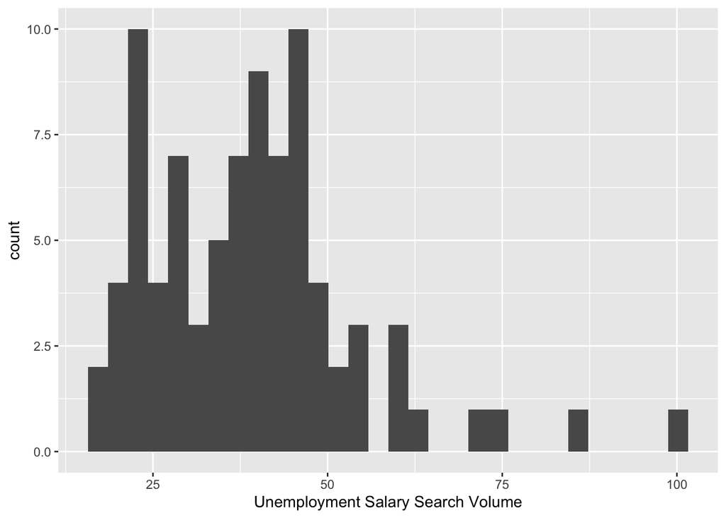

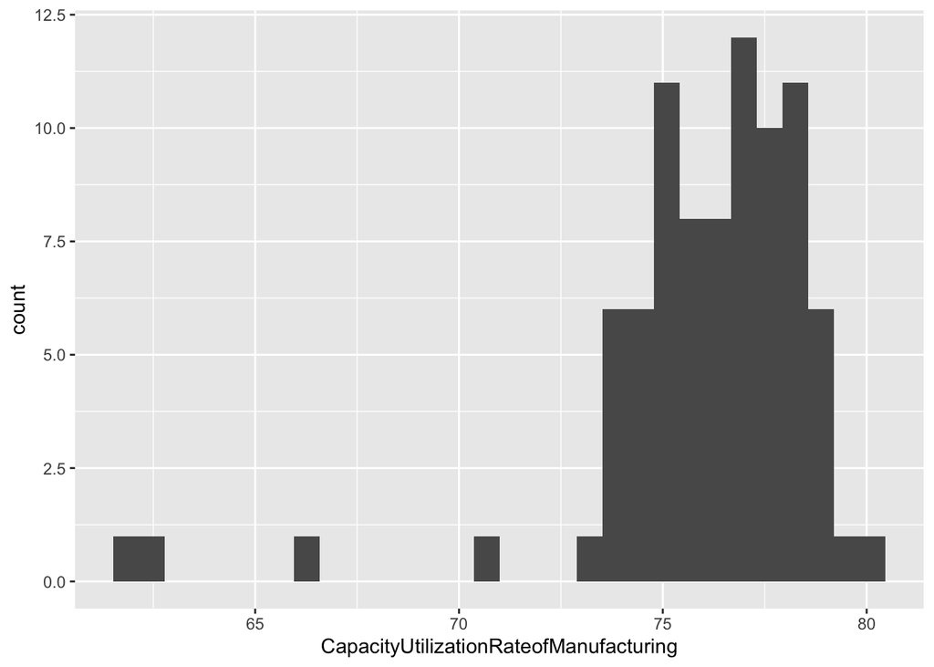

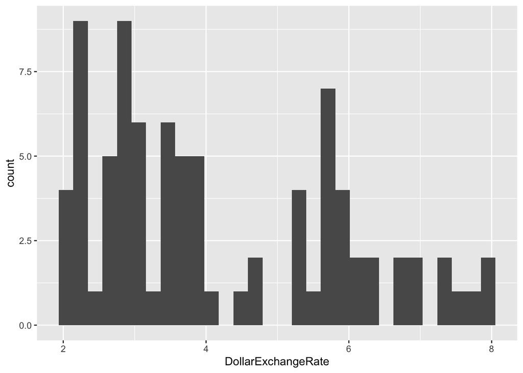

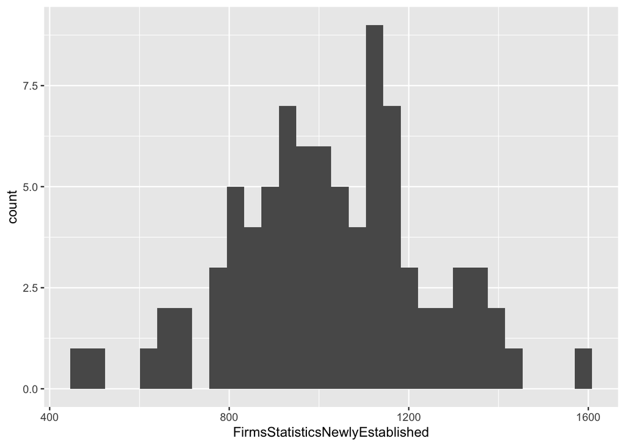

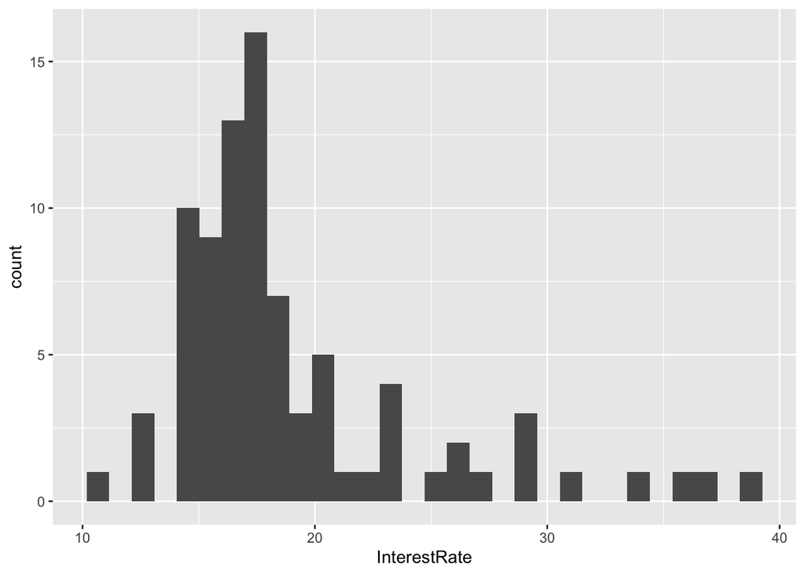

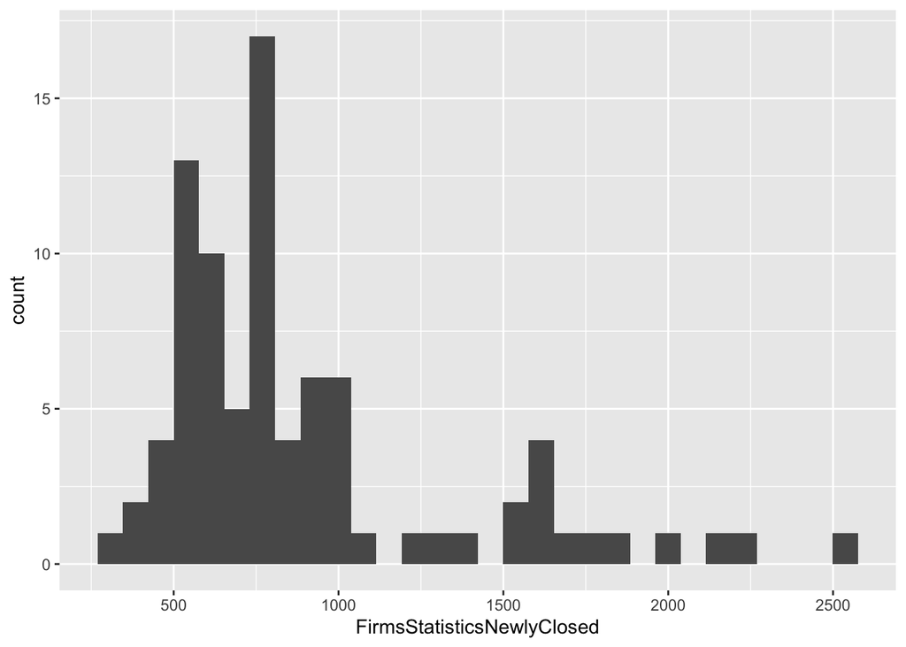

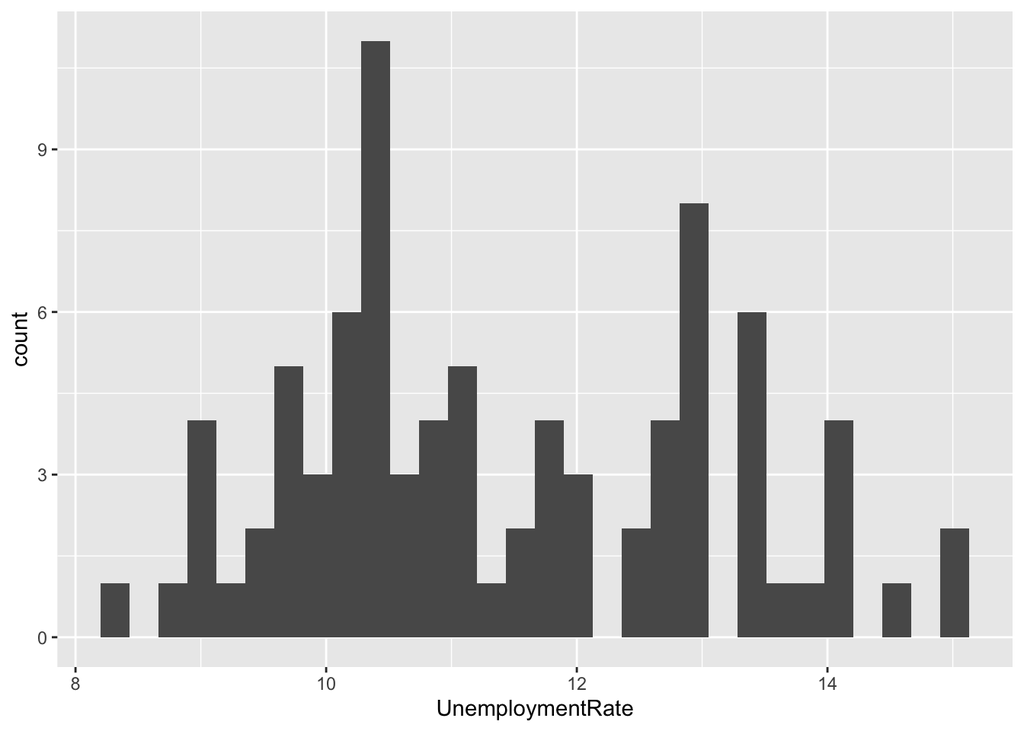

Dollar Exchange Rate and Interest Rate histograms seem similar to our search keyword volume histogram,which leads me to compute correlation of our keyword data and other measures that we were interested above.

```
## [1] -0.2707253
```

```
## [1] 0.5088294
```

```
## [1] -0.1406201
```

```
## [1] 0.458537
```

```
## [1] -0.0115184
```

(Correlation values respectively:Capacity Utilization Rate of Manufacturing,Dollar Exchange Rate,Firms Statistics Newly Established,Interest Rate,Firms Statistics Newly Closed) After calculating these values in R,that sort of proves that interest rate and dollar exchange rate has greater correlation values with our search keyword volume than others.